# Taller número 2 de Simulación

# **Grupo 2**

## **Integrantes:** *Liseth Recalde, Jorge Sosa*

### *Ejercicio 6*

Uno de los primeros generadores fue el denominado método de los cuadrados medios propuesto por Von Neumann (1946). Con este procedimiento se generan números pseudoaleatorios de 4 dgitos de la siguiente forma:

1. Se escoge un número de cuatro dígitos $x_{0}$ (semilla).
2. Se eleva al cuadrado $(x_{0}^{2})$ y se toman los cuatro dígitos centrales $(x_{1})$.
3. Se genera el número pseudo-aleatorio como:

$$\begin{aligned}
u_{1} = \frac{x_{1}}{10^{4}}
\end{aligned}$$
iv. Volver al paso ii y repetir el proceso.

Para obtener los $k$ (número par) dígitos centrales de $x_{i}^{2}$ se puede utilizar que:
$$\begin{aligned}
x_{i+1} = \Bigl\lfloor{\frac{\left(x_{i}^{2}-\Bigl\lfloor{\frac{x_{i}^{2}}{10^{(2k- \frac{k}{2})}}}\Bigr\rfloor10^{(2k-\frac{k}{2})}\right)}{10^{\frac{k}{2}}}}\Bigr\rfloor
\end{aligned}$$
El algoritmo está implementado en el fichero **RANDVN.R**. Estudiar las características del generador de cuadrados medios a partir de una secuencia de 500 valores obtenidos tomando como semilla inicial los cuatro primeros dígitos del DNI. Emplear únicamente métodos gráficos.

Acontinuación está la implementación del algoritmo del fichero RANDVN.R

```r
# ==================================================================
# Generador Von Neumann de números pseudoaleatorios
# ==================================================================

# Borrar todos los objetos (problemas semilla)
rm(list=ls(all=TRUE))

# ------------------------------------------------------------------
# initRANDVN(semilla,n)
#   Inicia el generador
#   n número de digitos centrales, 4 por defecto (debe ser un nº par)
#   Por defecto semilla del reloj
#   OJO: No se hace ninguna verificación de los parámetros
# ------------------------------------------------------------------
initRANDVN <- function(semilla=as.numeric(Sys.time()), n=4) {
  .semilla <<- as.double(semilla) %% 10^n  #Cálculos en doble precisión
  .n <<- n
  .aux <<- 10^(2*n-n/2)
  .aux2 <<- 10^(n/2)
  return(invisible(list(semilla=.semilla,n=.n)))
}

# ------------------------------------------------------------------
# RANDVN()
#   Genera un valor pseudoaleatorio con el generador de Von Neumann
#   Actualiza la semilla (si no existe llama a initRANDVN)
# ------------------------------------------------------------------
RANDVN <- function() {
    if (!exists(".semilla", envir=globalenv())) initRANDVN()
    z <- .semilla^2
    .semilla <<- trunc((z-trunc(z/.aux)*.aux)/.aux2)
    return(.semilla/10^.n)
}

# ------------------------------------------------------------------
# RANDVNN(n)
#   Genera un vector de valores pseudoaleatorios con el generador congruencial
#   (por defecto de dimensión 1000)
#   Actualiza la semilla (si no existe llama a initRANDVN)
# ------------------------------------------------------------------
RANDVNN <- function(n=1000) {
    x <- numeric(n)
    for(i in 1:n) x[i] <- RANDVN()
    return(x)
    # return(replicate(n,RANDVN()))  # Alternativa más rápida
}
```

Grafico Histograma

```r
initRANDVN(1722)
nsim <- 500
system.time(u <- RANDVNN(nsim))
```

```
##    user  system elapsed
##    0.03    0.00    0.03
```

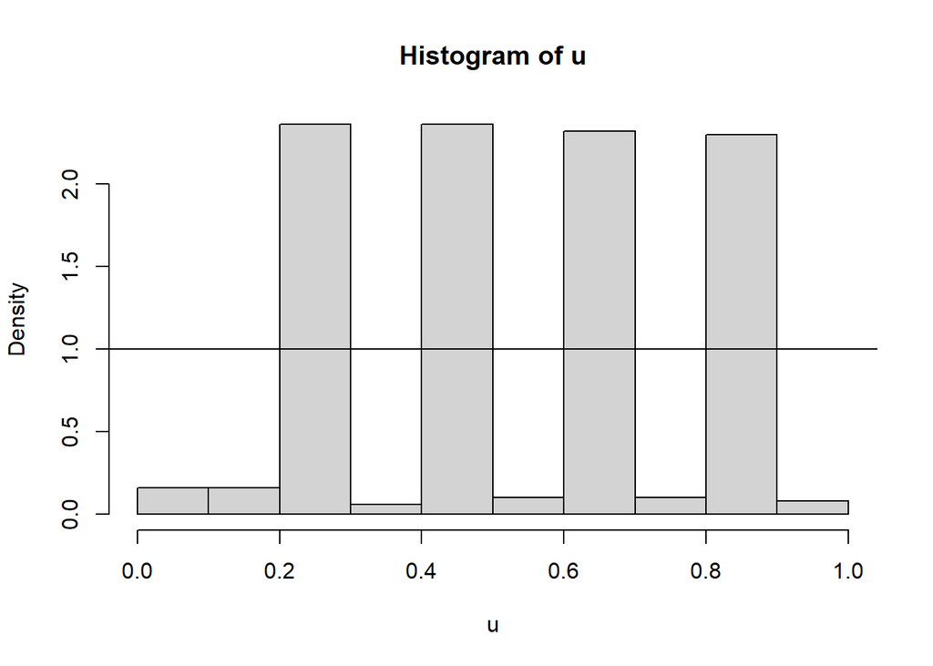

```r
hist(u, freq = FALSE)
abline(h = 1)
```

Podemos ver en el histograma que no concuerda con una adecuada distibución $U(0,1)$.

Grafico Secuencial

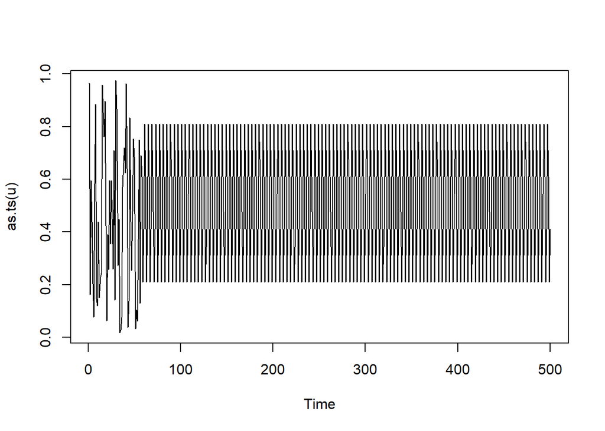

```r
plot(as.ts(u))
```

Se puede ver que al principio existe una posible independencia pero despues se ve claramente una dependencia negativa.

Gráfico de Dispersión retardado

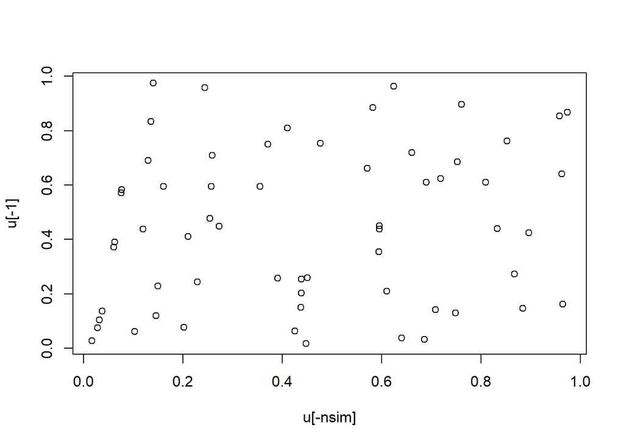

```r
plot(u[-nsim],u[-1])
```

Gráfico de Correlaciones

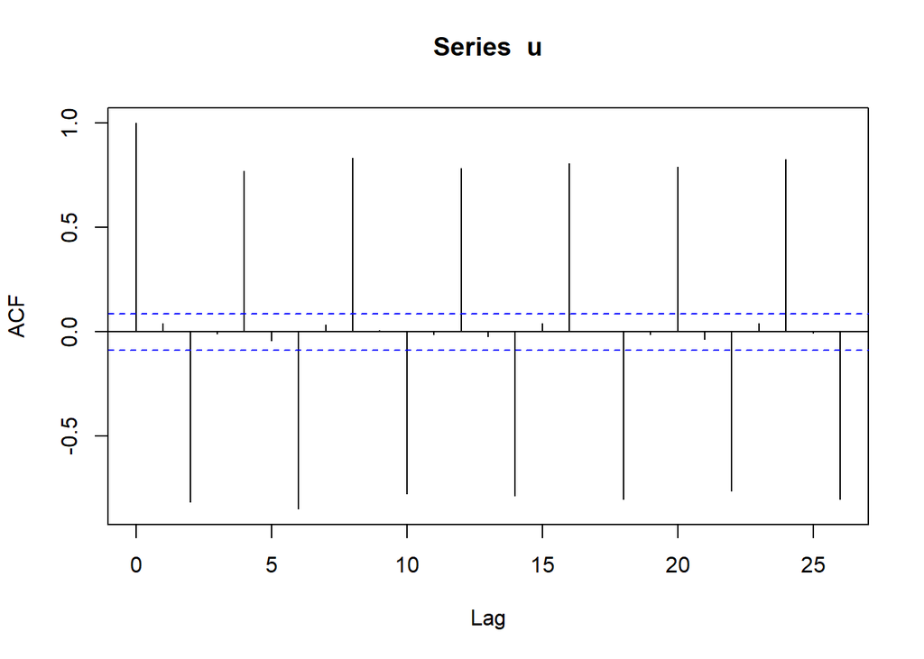

```r
acf(u)
```

### *Ejercicio 7*

Considerando el generador congruencial multiplicativo de parámetros $a = 7^{5} = 16807$, $c = 0$ y $m = 2^{31} -1$:

*a)¿Se observan los mismos problemas que con el algoritmo RANDU al considerar las tripletas $(x_{k};x_{k+1};x_{k+2})$?*

Obtendremos 9999 muestras de este generador para tener un ambiente similar de comparación al realizado con el algoritmo RANDU. Generador Congruencial Multiplicativo

```r
Gen_Congr <- function(a=16807,m=2^{31} -1,x0=12345) {
  x1 <- (a*x0)%%m
  return (x1)
}

GC_repetido<- function(x0=12345,n=9999) {
  x <- replicate(n,0)
  x[1]=x0
  for (i in 2:n) x[i] <- Gen_Congr(a=16807,m=2^{31} -1,x[i-1])
  return (x)
}
```

Generamos la muestra

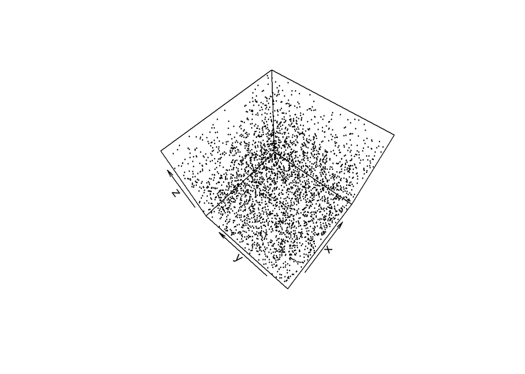

```r
muestra <-GC_repetido(x0 = 12345, n=9999)/(2^{31}-1)
P <- matrix(muestra, ncol = 3, byrow = TRUE)

library(plot3D)
points3D(P[,1], P[,2], P[,3], colvar = NULL, phi = 60,
         theta = -50, pch = 21, cex = 0.2)
```

En la gráfica no se muestran patrones en las diferentes tripletas por lo que, al menos en esta prueba, el método congruencial no posee los mismos problemas que el método RANDU.

*b)Estudiar la aleatoriedad de este generador empleando repetidamente el test de Ljung-Box, considerando $500$ pruebas con muestras de tamaño $50$ y hasta el salto $10$ $(Box.test(u,lag=10, type="Ljung"))$. Comparar gráficamente el ajuste de las distribuciones del estadístico y p-valor a las de referencia.*

Generamos las muestras del Método Congruencial utilizando como semillas valores generados por la función *sample*

```r
Y <- replicate(500,0) #vector de valores del estadístico
Z <- replicate(500,0) #vector de valores del p-valor
for (i in 1:500){
  A <- Box.test(GC_repetido(sample(1:10000,1),n=50)/(2^{31}-1) ,lag=10,type="Ljung-Box")
  Y[i] <- A[1] #Guardamos el estadístico
  Z[i] <- A[3] #Guardamos el p-valor
}
```

Ahora veamos la representación gráfica del Estadístico

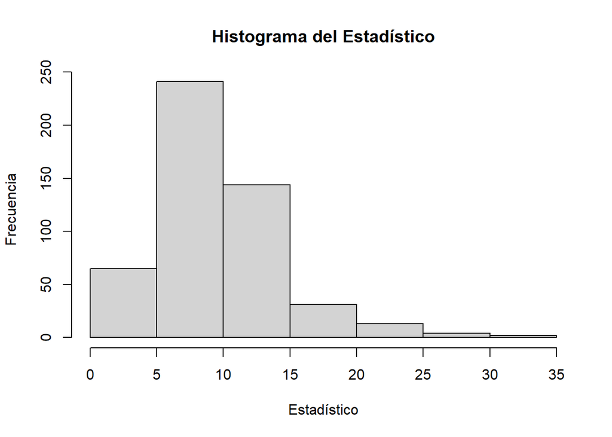

```r
hist(as.numeric(Y),main = paste("Histograma del Estadístico"),xlab ="Estadístico", ylab="Frecuencia",)
```

```r
mean(as.numeric(Y))
```

```
## [1] 9.479967
```

Mientras que la representación gráfica del p-valor tiene la forma

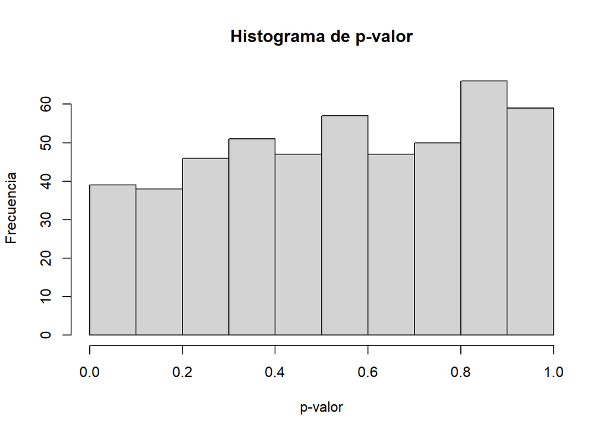

```r
hist(as.numeric(Z),main = paste("Histograma de p-valor"),xlab ="p-valor", ylab="Frecuencia",)
```

```r
mean(as.numeric(Z))
```

```
## [1] 0.5385415
```